# UNIVERSIDAD POLITECNICA SALESIANA

**Nombre:** María José Peláez

**Asignatura:** Simulación

## El juego de la Vida

El juego de la vida es un autómata celular diseñado por el matemático británico John Horton Conway en 1970

Se trata de un juego de cero jugadores, lo que quiere decir que su evolución está determinada por el estado inicial y no necesita ninguna entrada de datos posterior. El "tablero de juego" es una malla plana formada por cuadrados (las "células") que se extiende por el infinito en todas las direcciones. Por tanto, cada célula tiene 8 células "vecinas", que son las que están próximas a ella, incluidas las diagonales. Las células tienen dos estados: están "vivas" o "muertas" (o "encendidas" y "apagadas"). El estado de las células evoluciona a lo largo de unidades de tiempo discretas (se podría decir que por turnos). El estado de todas las células se tiene en cuenta para calcular el estado de las mismas al turno siguiente. Todas las células se actualizan simultáneamente en cada turno, siguiendo estas reglas:

#### **REGLAS DEL JUEGO**

Este juego está basado en la evolución de estados sucesivos, en los cuales las condiciones del estado futuro dependen solamente de las condiciones del estado anterior, por tanto no se requiere de la entrada de datos durante el desarrollo del mismo, y es tan sólo el estado inicial y las normas del juego lo que determinada el desarrollo del juego. Por tanto la participación en el mismo únicamente consiste en determinar las condiciones iniciales en función del resultado que se quiera obtener en un número de turnos concreto, o a perpetuidad.

El juego se desarrolla en un tablero (el “mundo”) infinito teóricamente, y de unas dimensionas prefijadas en la práctica, subdividido en forma de retícula mediante filas y columnas en celdas. Cada una de las celdas de la retícula quedan por tanto rodeadas por otras ocho casillas que determinan su “vecindad”.

Estas celdas albergan lo que se denominan “células” que pueden encontrarse en dos estados distintos, célula viva (podría considerarse un “uno lógico”) o célula muerta (“cero lógico”) el estado de una célula en el futuro dependerá tanto de su estado actual como del estado actual de sus células vecinas, siguiendo unas simples reglas establecidas. Una célula al morir deja vacía la celda que ocupaba.

Como ya se ha comentado el jugador es por tanto quien determina las condiciones iniciales de unas determinadas células, creando lo que se denomina “población inicial” o “generación cero”.

### **Reglas Originales**

**1-Supervivencia:** Cada individuo o célula que cumpla el requisito de tener 2 ó 3 vecinos vivos sobrevive a la siguiente generación (por tanto su estado se mantiene inalterado en el siguiente turno.

**2-Fallecimiento:** Una célula viva que tenga menos de 2 vecinos fallece por aislamiento o soledad en el siguiente estado o turno. Una célula viva que tenga más de trés vecinos vivos muere por superpoblación en el siguiente estado o turno.

**3-Nacimiento:** Si una celda vacía pasa a tener en su vecindad exactamente 3 células vivas su estado futuro en el siguiente turno será el de célula viva (nacimiento de nuevo individuo).

Según se empieza a experimentar se encuentra que la población empieza a evolucionar cambios insólitos o inesperados, a ojos del jugador estas reglas a veces crean la sensación de dar un resultado caótico e impredecible.

Normalmente según estas reglas se puede llegar a diversas situaciones finales trascurrido un número determinado de turnos:

**Extinción:** al cabo de un número finito de generaciones desaparecen todos los miembros de la población o células vivas.

**Estabilización:** al cabo de un número finito de generaciones la población queda estabilizada, bien de forma rígida e inamovible, bien de forma oscilante entre dos o más formas.

**Crecimiento constante:** la población crece turno tras turno y se mantiene así un número infinito de generaciones. En un principio esta evolución solo se contemplo de forma teórica, aunque más tarde se encontrarán patrones que crecían de forma indefinida, durante un numero infinito de turnos.

Estas reglas se denominan leyes genéticas de Conway y se simbolizan como “2,3 / 3” (condiciones de supervivencia / condiciones de nacimiento) y fueron las reglas originales formuladas por John Horton Conway, sin embargo no son las únicas, ya que existen variaciones de éstas.

### Patrones

- El bloque (Block): es el patrón inmortal más sencillo

[figure not shown]

- El doble bloque (Bi-block): es el patrón pseudo-inmortal más simple:

[figure not shown]

- La colmena (Beehive): pueden encontrarse de forma aislada, pero lo mas común esque aparezca de forma apareada o en grupos de cuatro, formando el patron pseudo-inmortal llamado “panal de miel” (Honey farm).

[figure not shown]

### Formulacion del Problema

#### Variables que rigen el sistema

En este sistema las celulas vivas son representados por un cuadrado y las celulas muertas son representados por un punto.

Al iniciar el sistema se le asigna tanto el número de columnas como el número de filas que deseamos, esto representa el espacio en donde se van a encontrar las células.

#### Resultados que se esperan del simulador

En ciertos casos apareceran las vidas estáticas son patrones que no cambian de una generación a la siguiente. Las vidas estáticas se puede considerar como osciladores de período 1. En general se asume que las vidas estáticas son finitas y no vacías

En ciertos casos apareceran las naves espaciales son patrones que reaparecen en otra posición tras completar su período. Esto es, son patrones que tras un número finito de generaciones vuelven a su estado original pero en una ubicación diferente.

Tambien aparecerá los matusalenes son patrones que pueden evolucionar a lo largo de muchos turnos, o generaciones, antes de estabilizarse.

Solamente se ingresa el numero de filas y columnas y el lugar en donde se van a ubicar las células es de forma aleatoria por esta razón los patrones que se vayan generando en cada partida van a ir cambiando.

#### Tiempo disponible

El tiempo que va a responder el sistema depende de dos factores el número de filas y columnas que ingresemos, las posiciones de cada célula y de acuerdo a las reglas del juego el tiempo puede variar.

#### Plan de experimentación

Depende el número aleatorio de celulas vivas y muertas que se ingresen al sistema.

Ejecutar continuamente el sistema para observar la variación de las células, que tan seguido ocurre y si en algún caso existe una situación de celulas estaticas.

#### Plan de pruebas

```
FIlas: 4
Columnas: 4
 ■  ■  .  .
 .  .  ■  .
 ■  .  .  ■
 ■  ■  .  ■
Life: 1 Dead: 3
Total iteraciones:  1
 .  ■  .  .
 ■  .  ■  .
 ■  .  .  ■
 ■  ■  ■  .
Life: 2 Dead: 2
Total iteraciones:  2
 .  ■  .  .
 ■  .  ■  .
 ■  .  .  ■
 ■  ■  ■  .
Life: 0 Dead: 0
Total iteraciones:  3
```

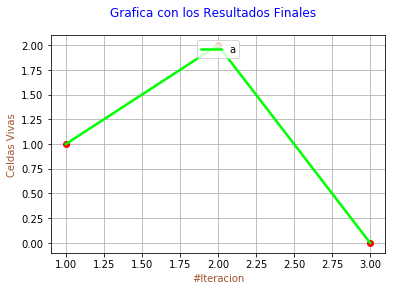

```python
# -*- coding: utf-8 -*-

from __future__ import print_function

import copy
import random
import itertools
import time
import os
import xlsxwriter
import matplotlib.pyplot as pp

UNIX = True  # Change if using Windows

clear = lambda: os.system('clear') if UNIX else os.system('cls')


class GameOfLife(object):

    def __init__(self, rows, cols):

        self.rows = rows
        self.cols = cols

        row_life = lambda: [random.randint(0, 1) for n in range(self.cols)]
        self.game = [row_life() for n in range(self.rows)]

        self.life = 1
        self.dead = 1
        self.resultados = []
        self.iteracion=[]

    def __str__(self):

        table = ''
        for row in self.game:
            for cell in row:
                table += ' ■ ' if cell else ' . '

            table += '\n'
        table += "Life: {0} Dead: {1}".format(self.life, self.dead)
        self.resultados.append([self.life,self.dead])
        return table

    def evaluate(self, row, col):

        distance = list(set(itertools.permutations([-1, -1, 1, 1, 0], 2)))
        into_table = lambda x, y: (x in range(self.rows) and y in range(self.cols))

        total = 0
        for r, c in distance:
            if into_table(r + row, c + col):
                total += self.game[r + row][c + col]
        return total

    def test(self):

        gameaux = copy.deepcopy(self.game)
        self.life = 0
        self.dead = 0

        for r in range(self.rows):
            for c in range(self.cols):
                total = self.evaluate(r, c)

                if (total < 2 or total > 3) and gameaux[r][c]:
                    gameaux[r][c] = 0 #MOrir
                    self.dead += 1
                elif total == 3 and not gameaux[r][c]:
                    gameaux[r][c] = 1 #Nacer o seguir viva
                    self.life += 1

        self.game = copy.deepcopy(gameaux)

    def crearGrafica(self):
        x = []
        y = []
        for i in self.resultados:

                y.append(i[0])


        for j in self.iteracion:
                x.append(j[0])

        pp.plot(x, y, 'ro')
        pp.suptitle("Grafica con los Resultados Finales", color="blue")
        pp.plot(x, y, color="lime", linewidth=2.5, linestyle="-", label="a")
        pp.xlabel("#Iteracion", color="sienna")
        pp.ylabel("Celdas Vivas", color="sienna")
        pp.legend(loc='upper center')
        pp.grid(True)
        # pp.set_title('Grafica Final')
        pp.savefig('grafico.png')
        pp.show()

    def crearExcel(self):
        workbook = xlsxwriter.Workbook('GraficaResultados.xlsx')
        worksheet = workbook.add_worksheet()
        cell_format = workbook.add_format()
        cell_format.set_bold()
        cell_format.set_italic()
        cell_format.set_font_color('red')
        cell_format.set_font_size(13)

        cell_format2 = workbook.add_format()
        cell_format2.set_align("center")
        cell_format2.set_bold()

        cell_format3 = workbook.add_format()
        cell_format3.set_align("center")

        worksheet.set_column('A:A', 15)
        worksheet.set_column('B:B', 15)

        bold = workbook.add_format({'bold': True})

        worksheet.write(0, 0, 'Realizado por:',cell_format)
        worksheet.write(0, 1, 'María José Peláez', cell_format)
        worksheet.write(2, 0, 'RESULTADOS ',bold)
        worksheet.write(4, 0, '# Celdas Iniciales:',bold)
        worksheet.write(4, 2, self.rows,cell_format2)
        worksheet.write(5, 0, '---------------------------------------------------------')
        worksheet.write(6, 1, '# Celdas Muertas',cell_format2)
        worksheet.write(6, 0, '# Celdas Vivas',cell_format2)
        worksheet.insert_image(0, 5, 'grafico.png')
        # Start from the first cell. Rows and columns are zero indexed.
        row = 7
        col = 0

        # Iterate over the data and write it out row by row.
        for i, c in self.resultados:
            worksheet.write(row, col, i,cell_format3)
            worksheet.write(row, col + 1, c,cell_format3)
            row += 1
        workbook.close()

rows, cols = int(input("FIlas: ")), int(input("Columnas: "))
game = GameOfLife(rows, cols)

iterations = 0

while game.life > 0 or game.dead > 0:
    try:
        clear()
        game.test()
        print(game)
        time.sleep(1)
        iterations += 1
        game.iteracion.append([iterations])
        print("Total iteraciones: ", iterations)
    except KeyboardInterrupt:
        break
game.crearGrafica()
game.crearExcel()
#print("Total iteraciones: ", iterations)
```

### Referencias:

Edwin Martin. (S/N). Game of Life. 30/04/2019, de bitstorm Sitio web: https://bitstorm.org/gameoflife/

JChambilla, D. E. F. El Juego de la Vida de Conway.

Fernandez Chambilla, D. E. (2010). El Juego de la Vida de Conway. Revista de Información, Tecnología y Sociedad, 33.